# Алгоритмы интеллектуальной обработки больших объемов данных

## Домашнее задание №2: Линейные модели

###### <hr>

**Общая информация**

**Срок сдачи:** 05 апреля 18:00 Сдача **очная** на онлайн занятии. <br>

Используйте данный Ipython Notebook при оформлении домашнего задания.

Присылать ДЗ необходимо в виде ссылки на свой github репозиторий на почту ml1.sphere@mail.ru с указанием темы в следующем формате:

[ML0920, Задание 2] Фамилия Имя.

**Штрафные баллы:**

1. Невыполнение PEP8 -1 балл
2. Отсутствие фамилии в имени скрипта (скрипт должен называться по аналогии со stroykova_hw2.ipynb) -1 балл
3. Все строчки должны быть выполнены. Нужно, чтобы output команды можно было увидеть уже в git'е. В противном случае -1 балл
4. При оформлении ДЗ нужно пользоваться данным файлом в качестве шаблона. Не нужно удалять и видоизменять написанный код и текст, если явно не указана такая возможность. В противном случае -1 балл <hr>

```python
import pandas as pd
import numpy as np
import matplotlib.pyplot as plt
import sklearn

%matplotlib inline

plt.style.use('ggplot')
plt.rcParams['figure.figsize'] = (12, 5)
```

Здравствуйте, уважаемые студенты!

В этом задании мы будем реализовать линейные модели. Необходимо реализовать линейную и логистическую регрессии с L2 регуляризацией

# Теоретическое введение

Линейная регрессия решает задачу регрессии и оптимизирует функцию потерь MSE

$$L(w) = \frac{1}{N}\left[\sum_i (y_i - a_i) ^ 2 \right], $$

где $y_i$ $-$ целевая функция, $a_i = a(x_i) = \langle\,x_i,w\rangle ,$ $-$ предсказание алгоритма на объекте $x_i$, $w$ $-$ вектор весов (размерности $D$), $x_i$ $-$ вектор признаков (такой же размерности $D$).

Не забываем, что здесь и далее мы считаем, что в $x_i$ есть тождественный вектор единиц, ему соответствует вес $w_0$.

Логистическая регрессия является линейным классификатором, который оптимизирует так называемый функционал log loss:

$$L(w) = - \frac{1}{N}\left[\sum_i y_i \log a_i + ( 1 - y_i) \log (1 - a_i) \right],$$

где $y_i \in \{0,1\}$ $-$ метка класса, $a_i$ $-$ предсказание алгоритма на объекте $x_i$. Модель пытается предсказать апостериорую вероятность объекта принадлежать к классу "1": $$ p(y_i = 1 | x_i) = a(x_i) = \sigma( \langle\,x_i,w\rangle ),$$ $w$ $-$ вектор весов (размерности $D$), $x_i$ $-$ вектор признаков (такой же размерности $D$).

Функция $\sigma(x)$ $-$ нелинейная функция, пероводящее скалярное произведение объекта на веса в число $\in (0,1)$ (мы же моделируем вероятность все-таки!)

$$\sigma(x) = \frac{1}{1 + \exp(-x)}$$

Если внимательно посмотреть на функцию потерь, то можно заметить, что в зависимости от правильного ответа алгоритм штрафуется или функцией $-\log a_i$, или функцией $-\log (1 - a_i)$.

Часто для решения проблем, которые так или иначе связаны с проблемой переобучения, в функционал качества добавляют слагаемое, которое называют *регуляризацией*. Итоговый функционал для линейной регрессии тогда принимает вид:

$$L(w) = \frac{1}{N}\left[\sum_i (y_i - a_i) ^ 2 \right] + \frac{1}{C}R(w) $$

Для логистической: $$L(w) = - \frac{1}{N}\left[\sum_i y_i \log a_i + ( 1 - y_i) \log (1 - a_i) \right] + \frac{1}{C}R(w)$$

Самое понятие регуляризации введено основателем ВМК академиком Тихоновым https://ru.wikipedia.org/wiki/Метод_регуляризации_Тихонова

Идейно методика регуляризации заключается в следующем $-$ мы рассматриваем некорректно поставленную задачу (что это такое можно найти в интернете), для того чтобы сузить набор различных вариантов (лучшие из которых будут являться переобучением) мы вводим дополнительные ограничения на множество искомых решений. На лекции Вы уже рассмотрели два варианта регуляризации.

$L1$ регуляризация: $$R(w) = \sum_{j=1}^{D}|w_j|$$ $L2$ регуляризация: $$R(w) = \sum_{j=1}^{D}w_j^2$$

С их помощью мы ограничиваем модель в возможности выбора каких угодно весов минимизирующих наш лосс, модель уже не сможет подстроиться под данные как ей угодно.

Вам нужно добавить соотвествущую Вашему варианту $L2$ регуляризацию.

И так, мы поняли, какую функцию ошибки будем минимизировать, разобрались, как получить предсказания по объекту и обученным весам. Осталось разобраться, как получить оптимальные веса. Для этого нужно выбрать какой-то метод оптимизации.

Градиентный спуск является самым популярным алгоритмом обучения линейных моделей. В этом задании Вам предложат реализовать стохастический градиентный спуск или мини-батч градиентный спуск (мини-батч на русский язык довольно сложно перевести, многие переводят это как "пакетный", но мне не кажется этот перевод удачным). Далее нам потребуется определение **эпохи**. Эпохой в SGD и MB-GD называется один проход по **всем** объектам в обучающей выборки.

- В SGD градиент расчитывается по одному случайному объекту. Сам алгоритм выглядит примерно так:

  ```
    1) Перемешать выборку
    2) Посчитать градиент функции потерь на одном объекте (далее один объект тоже будем называть батчем)
    3) Сделать шаг спуска
    4) Повторять 2) и 3) пока не пройдет максимальное число эпох.
  ```

- В Mini Batch SGD - по подвыборке объектов. Сам алгоритм выглядит примерно так::

  ```
    1) Перемешать выборку, выбрать размер мини-батча (от 1 до размера выборки)
    2) Почитать градиент функции потерь по мини-батчу (не забыть поделить на  число объектов в мини-батче)
    3) Сделать шаг спуска
    4) Повторять 2) и 3) пока не пройдет максимальное число эпох.
  ```

- Для отладки алгоритма реализуйте возможность вывода средней ошибки на обучении модели по объектам (мини-батчам). После шага градиентного спуска посчитайте значение ошибки на объекте (или мини-батче), а затем усредните, например, по ста шагам. Если обучение проходит корректно, то мы должны увидеть, что каждые 100 шагов функция потерь уменьшается.
- Правило останова - максимальное количество эпох

# Теоретические вопросы (2 балла)

В этой части Вам будут предложены теоретичские вопросы и задачи по теме. Вы, конечно, можете списать их у своего товарища или найти решение в интернете, но учтите, что они обязательно войдут в теоретический коллоквиум. Лучше разобраться в теме сейчас и успешно ответить на коллоквиуме, чем списать, не разобравшись в материале, и быть терзаемым совестью.

Формулы надо оформлять в формате **LaTeX**.

Задача 1. Градиент для линейной регрессии.

- Выпишите формулу обновления весов для линейной регрессии с L2 регуляризацией для мини-батч градиентого спуска размера $n$: $$ w_{new}\ =\ w_{old}\ -\ ... $$ Отнеситесь к этому пункту максимально серьезно, это Вам нужно будет реализовать в задании.

Проанализруйте итоговую формулу градиента - как интуитивно можно описать, чему равен градиент?

$$x_i = \left(1,\ x_i^{(1)},\ ...,\ x_i^{(D)}\right)$$

$$ L^{(n)}(w) = \frac{1}{n} \sum_{i = 1}^{n}(a(x_i) - y_i)^2 + \frac{1}{C} \sum_{j = 1}^{D}w_j^2 $$

$$L_{w_0}^{(n)'} = \frac{2}{n} \sum_{i = 1}^{n}(a(x_i) - y_i)$$

$$L_{w_j, j \neq 0}^{(n)'} = \frac{2}{n} \sum_{i = 1}^{n}x_i^{(j)}(a(x_i) - y_i) + \frac{2w_j}{C}$$

$$ w_{new} = w_{old} - \lambda\left(\frac{2}{n} \sum_{i = 1}^{n}(a(x_i) - y_i), \frac{2}{n}\sum_{i = 1}^{n}x_i^{(1)}(a(x_i) - y_i) + \frac{2w_1}{C},\ ..., \frac{2}{n}\sum_{i = 1}^{n}x_i^{(D)}(a(x_i) - y_i) + \frac{2w_D}{C}\right)$$

$$ w_{new} = w_{old} - 2\lambda\left(\frac{1}{n} \sum_{i = 1}^{n} (a(x_i) - y_i)(1, x_i^{(1)},\ ..., x_i^{(D)}) +\frac{1}{C}(w_1,\ ..., w_D)\right) $$

$$ w_{new} = w_{old} - 2\lambda\left(\frac{1}{n} \sum_{i = 1}^{n} (a(x_i) - y_i)x_i +\frac{1}{C}w_{old}\right) $$

*По формуле градиента видно, что он равен вектору суммы вектора направления наибольшего возрастания исходной функции эмпирического риска и текущего вектора весов с некторым коэфициентом. Т.е. мы пытаемся сделать шаг в таком направлении, чтобы в среднем уменьшить и ошибку алгоритма, и меру вектора весов.*

Задача 2. Градиент для логистической регрессии.

- Выпишите формулу обновления весов для логистической регрессии с L2 регуляризацией для мини-батч градиентого спуска размера $n$: $$ w_{new}\ =\ w_{old}\ -\ ... $$

  Отнеситесь к этому пункту максимально серьезно, это Вам нужно будет реализовать в задании.

Проанализруйте итоговую формулу градиента - как интуитивно можно описать, чему равен градиент? Как соотносится этот градиент с градиентом, возникающий в задаче линейной регрессии?

Подсказка: Вам градиент, которой получается если “в лоб” продифференцировать, надо немного преобразовать. Надо подставить, что $1 - \sigma(w,x) $ это $1 - a(x_i)$, а $-\sigma(w,x)$ это $0 - a(x_i)$. Тогда получится свести к одной красивой формуле с линейной регрессией, которую программировать будет намного проще.

$$x_i = (1,\ x_i^{(1)},\ ...,\ x_i^{(D)})$$

$$ L^{(n)}(w) = -\frac{1}{n} \sum_{i = 1}^{n} \left[y_i\log{a_i} + (1 - y_i)\log(1 - a_i)\right] + \frac{1}{C}\sum_{j = 1}^{D}w_j^2 $$

$$ L_{w_0}^{(n)'} = \frac{1}{n}\sum_{i = 1}^{n} \left[ \frac{-y_i e^{^{-\langle x_i, w \rangle}}}{1 + e^{-\langle x_i, w \rangle}} + \frac{1 - y_i}{1 + e^{-\langle x_i, w \rangle}} \right] = \frac{1}{n} \sum_{i = 1}^{n} \left[ -y_i(1 - a(x_i) + (1 - y_i)a(x_i) \right] = \frac{1}{n} \sum_{i = 1}^{n} (a(x_i) - y_i) $$

$$ L_{w_j, j \neq 0}^{(n)'} = \frac{1}{n}\sum_{i = 1}^{n} \left[ \frac{-y_i x_i^{(j)} e^{^{-\langle x_i, w \rangle}}}{1 + e^{-\langle x_i, w \rangle}} + \frac{(1 - y_i) x_i^{(j)}}{1 + e^{-\langle x_i, w \rangle}} \right] + \frac{w_j}{C}= \frac{1}{n} \sum_{i = 1}^{n} x_i^{(j)} \left[ -y_i(1 - a(x_i) + (1 - y_i)a(x_i) \right] + \frac{2w_j}{C} = \\ = \frac{1}{n} \sum_{i = 1}^{n} x_i^{(j)}(a(x_i) - y_i) + \frac{2w_j}{C}$$

$$ w_{new} = w_{old} - \lambda\left(\frac{1}{n} \sum_{i = 1}^{n}(a(x_i) - y_i), \frac{1}{n}\sum_{i = 1}^{n}x_i^{(1)}(a(x_i) - y_i) + \frac{2w_1}{C},\ ..., \frac{1}{n}\sum_{i = 1}^{n}x_i^{(D)}(a(x_i) - y_i) + \frac{2w_D}{C}\right)$$

$$ w_{new} = w_{old} - \lambda\left(\frac{1}{n} \sum_{i = 1}^{n} (a(x_i) - y_i)x_i +\frac{2}{C}w_{old}\right) $$

*Видно, что формула градиентного спуска для логистической регрессии с точностью до коэфицентов совпадает с формулой для линейной регресии. Соответственно, как и в линейной регрессии, мы пытаемся сделать шаг в таком направлении, чтобы в среднем и приблизить истинные вероятности принадлежности объекта к классу "1", и уменьшить меру вектора весов.*

Задача 3. Точное решение линейной регрессии

На лекции было показано, что точное решение линейной регрессии имеет вид $ w = (X^TX)^{-1}X^TY $.

- Покажите, что это действительно является точкой минимума в случае, если матрица X имеет строк не меньше, чем столбцов и имеет полный ранг. Подсказка: посчитайте Гессиан и покажите, что в этом случае он положительно определен.
- Выпишите точное решение для модели с $L2$ регуляризацией. Как L2 регуляризация помогает с точным решением где матрица X имеет линейно зависимые признаки?

**Приведем функцию эмпирического риска к матричному виду:** $$ L(w)=\frac{1}{n}\left(Xw-y\right)^T \left(Xw-y\right) + \frac{1}{C} w^Tw = \frac{1}{n} \left(w^TX^TXw-w^TX^Ty-y^TXw+y^Ty\right). $$

**Выпишем градиент в матричном виде:** $$ \nabla_w L(w) = \frac{2}{n}\left(X^TXw - X^Ty \right). $$

**Пользуясь градиентом, посчитаем Гессиан: $$ \nabla_w^2 L(w) = \nabla_w \left(\frac{2}{n}\left(X^TXw-2X^Ty\right)\right)=\frac{2}{n}X^TX. $$ Матрица $X^TX$ имеет тот же ранг, что и $ X \Rightarrow X^TX $ невырождена $ \Rightarrow $ обратима и можно выписать решение $ w = (X^TX)^{-1}X^Ty $, которое является станционарной точкой: $$ \nabla_w L((X^TX)^{-1}X^Ty) = \frac{2}{n}\left(X^TX(X^TX)^{-1}X^Ty - X^Ty \right) = \frac{2}{n}\left(X^Ty - X^Ty \right) = 0, $$ причем Гессиан положительно определен:** $$ x^T\left(\frac{2}{n}X^TX\right)x = \frac{2}{n}x^T(X^TX)x = \frac{2}{n}(Xx)^T(Xx) > 0. $$

Задача 4. Предсказываем вероятности.

Когда говорят о логистической регрессии, произносят фразу, что она "предсказывает вероятности положительного класса". Давайте разберемся, что же за этим стоит. Посчитаем математическое ожидание функции потерь и проверим, что предсказание алгоритма, оптимизирующее это мат. ожидание, будет являться вероятностью положительного класса.

И так, функция потерь на объекте $x_i$, который имеет метку $y_i \in \{0,1\}$ для предсказания $a(x_i)$ равна: $$L(y_i, b) =-[y_i == 1] \log a(x_i) - [y_i == 0] \log(1 - a(x_i)) $$

Где $[]$ означает индикатор $-$ он равен единице, если значение внутри него истинно, иначе он равен нулю. Тогда мат. ожидание при условии конкретного $x_i$ по определение мат. ожидания дискретной случайной величины: $$E(L | x_i) = -p(y_i = 1 |x_i ) \log a(x_i) - p(y_i = 0 | x_i) \log( 1 - a(x_i))$$

- Докажите, что значение $a(x_i)$, минимизирующее данное мат. ожидание, в точности равно $p(y_i = 1 |x_i)$, то есть равно вероятности положительного класса.

Подсказка: возможно, придется воспользоваться, что $p(y_i = 1 | x_i) + p(y_i = 0 | x_i) = 1$

**Воспользуемся необходимым условием максимум функции:** $$ \frac{d(E(L | x_i))}{da} = -p(y_i = 1 | x_i)\frac{1}{a(x_i)} + p(y_i = 0 | x_i)\frac{1}{1- a(x_i)} = 0. $$ **Воспользуемся тем, что $p(y_i = 1 | x_i) + p(y_i = 0 | x_i) = 1$:** $$ \frac{d(E(L | x_i))}{da} \cdot a(x_i)(1 - a(x_i)) = p(y_i = 1 | x_i)(a(x_i) - 1) + p(y_i = 0 | x_i)a(x_i) = p(y_i = 1 | x_i)(a(x_i) - 1) + (1 - p(y_i = 1 | x_i))a(x_i) = \\= a(x_i) - p(y_i = 1 | x_i) = 0 \Leftrightarrow a(x_i) = p(y_i = 1 | x_i). $$

Задача 5. Смысл регуляризации.

Нужно ли в L1/L2 регуляризации использовать свободный член $w_0$ (который не умножается ни на какой признак)?

Подсказка: подумайте, для чего мы вводим $w_0$

**Свободный член $w_0$ задает смещение разделяющей гиперплоскости, поэтому применять к нему регуляризацию было бы неправильно**.

# Реализация линейной модели (4 балла)

## Зачем нужны батчи?

Как Вы могли заметить из теоретического введения, что в случае SGD, что в случа mini-batch GD, на каждой итерации обновление весов происходит только по небольшой части данных (1 пример в случае SGD, batch примеров в случае mini-batch). То есть для каждой итерации нам **не нужна вся выборка**. Мы можем просто итерироваться по выборке, беря батч нужного размера (далее 1 объект тоже будем называть батчом).

Легко заметить, что в этом случае нам не нужно загружать все данные в оперативную память, достаточно просто считать батч с диска, обновить веса, считать с диска другой батч и так далее. В целях упрощения домашней работы, прямо с диска мы считывать не будем, будем работать с обычными numpy array.

## Немножко про генераторы в Python

Идея считывания данных кусками удачно ложится на так называемые *генераторы* из языка Python. В данной работе Вам предлагается не только разобраться с логистической регрессией, но и познакомиться с таким важным элементом языка. При желании Вы можете убрать весь код, связанный с генераторами, и реализовать логистическую регрессию и без них, *штрафоваться это никак не будет*. Главное, чтобы сама модель была реализована правильно, и все пункты были выполнены.

Подробнее можно почитать вот тут https://anandology.com/python-practice-book/iterators.html

К генератору стоит относиться просто как к функции, которая порождает не один объект, а целую последовательность объектов. Новое значение из последовательности генерируется с помощью ключевого слова *yield*. Ниже Вы можете насладиться генератором чисел Фибоначчи.

```python
def fib(max_iter=4):
    a, b = 0, 1
    iter_num = 0
    while 1:
        yield a
        a, b = b, a + b
        iter_num += 1
        if iter_num == max_iter:
            break
```

Вот так можно сгенерировать последовательность Фибоначчи.

Заметьте, что к генераторам можно применять некоторые стандартные функции из Python, например enumerate.

```python
new_generator = fib()
for j, fib_val in enumerate(new_generator):
    print ("Fib num: " + str(j) + " fib values: " + str(fib_val))
```

```
Fib num: 0 fib values: 0
Fib num: 1 fib values: 1
Fib num: 2 fib values: 1
Fib num: 3 fib values: 2
```

Пересоздавая объект, можно сколько угодно раз генерировать заново последовательность.

```python
for i in range(0, 3):
    new_generator = fib()
    for j, fib_val in enumerate(new_generator):
        print ("Fib num: " + str(j) + " fib values: " + str(fib_val))
```

```
Fib num: 0 fib values: 0
Fib num: 1 fib values: 1
Fib num: 2 fib values: 1
Fib num: 3 fib values: 2
Fib num: 0 fib values: 0
Fib num: 1 fib values: 1
Fib num: 2 fib values: 1
Fib num: 3 fib values: 2
Fib num: 0 fib values: 0
Fib num: 1 fib values: 1
Fib num: 2 fib values: 1
Fib num: 3 fib values: 2
```

А вот так уже нельзя.

```python
new_generator = fib()
for i in range(0, 3):
    for j, fib_val in enumerate(new_generator):
        print ("Fib num: " + str(j) + " fib values: " + str(fib_val))
```

```
Fib num: 0 fib values: 0
Fib num: 1 fib values: 1
Fib num: 2 fib values: 1
Fib num: 3 fib values: 2
```

Концепция крайне удобная для обучения моделей $-$ у Вас есть некий источник данных, который Вам выдает их кусками, и Вам совершенно все равно откуда он их берет. Под ним может скрывать как массив в оперативной памяти, как файл на жестком диске, так и SQL база данных. Вы сами данные никуда не сохраняете, оперативную память экономите.

Если Вам понравилась идея с генераторами, то Вы можете реализовать свой, используя прототип batch_generator. В нем Вам нужно выдавать батчи признаков и ответов для каждой новой итерации спуска. Если не понравилась идея, то можете реализовывать SGD или mini-batch GD без генераторов.

```python
def batch_generator(X, y, shuffle=True, batch_size=1):
    """
    Гератор новых батчей для обучения
    X          - матрица объекты-признаки
    y_batch    - вектор ответов
    shuffle    - нужно ли случайно перемешивать выборку
    batch_size - размер батча (1 это SGD, > 1 mini-batch GD)
    Генерирует подвыборку для итерации спуска (X_batch, y_batch)
    """

    if shuffle:
        X, y = sklearn.utils.shuffle(X, y)

    for i in range(0, X.shape[0], batch_size):
        X_batch = X[i : i + batch_size]
        y_batch = y[i : i + batch_size]
        yield (X_batch, y_batch)

# Теперь можно сделать генератор по данным ()
#  my_batch_generator = batch_generator(X, y, shuffle=True, batch_size=1):
```

```python
#%%pycodestyle
from sklearn.base import BaseEstimator, ClassifierMixin


def sigmoid(x):
    """
    Вычисляем значение сигмоида.
    X - выход линейной модели
    """

    return 1 / (1 + np.exp(-x))


class MySGDClassifier(BaseEstimator, ClassifierMixin):


    def __init__(self, batch_generator, C=1, alpha=0.01,
                 max_epoch=10, model_type='lin_reg'):
        """
        batch_generator -- функция генератор, которой будем создавать батчи
        C - коэф. регуляризации
        alpha - скорость спуска
        max_epoch - максимальное количество эпох
        model_type - тим модели, lin_reg или log_reg
        """
        self.C = C
        self.alpha = alpha
        self.max_epoch = max_epoch
        self.batch_generator = batch_generator
        self.errors_log = {'iter' : [], 'loss' : []}
        self.model_type = model_type
        self.weights = None

    def __a(self, X):

        y_hat = X @ self.weights

        if self.model_type == 'log_reg':
            y_hat = sigmoid(y_hat)

        return y_hat

    def calc_loss(self, X_batch, y_batch):
        """
        Считаем функцию потерь по батчу
        X_batch - матрица объекты-признаки по батчу
        y_batch - вектор ответов по батчу
        Не забудте тип модели (линейная или логистическая регрессия)!
        """
        loss = None

        if self.model_type == 'lin_reg':
            pred = self.__a(X_batch)
            loss = (pred - y_batch) ** 2
            loss = np.mean(loss, axis=0) + self.weights[1:].T @ self.weights[1:] / self.C
        elif self.model_type == 'log_reg':
            pred = self.__a(X_batch)
            loss = -(y_batch * np.log(pred) + (1 - y_batch) * np.log(1 - pred))
            loss = np.mean(loss, axis=0) + self.weights[1:].T @ self.weights[1:] / self.C

        return loss

    def calc_loss_grad(self, X_batch, y_batch):
        """
        Считаем  градиент функции потерь по батчу (то что Вы вывели в задании 1)
        X_batch - матрица объекты-признаки по батчу
        y_batch - вектор ответов по батчу
        Не забудте тип модели (линейная или логистическая регрессия)!
        """

        loss_grad = None

        if self.model_type == 'lin_reg':
            pred = self.__a(X_batch)
            reg = 2 * self.weights / self.C
            reg[0] = 0
            loss_grad = 2 * X_batch.T @ (pred - y_batch) / X_batch.shape[0] + reg
        elif self.model_type == 'log_reg':
            pred = self.__a(X_batch)
            reg = 2 * self.weights / self.C
            reg[0] = 0
            loss_grad = X_batch.T @ (pred - y_batch) / X_batch.shape[0] + reg

        return loss_grad

    def update_weights(self, new_grad):
        """
        Обновляем вектор весов
        new_grad - градиент по батчу
        """

        self.weights = self.weights - self.alpha * new_grad

    def fit(self, X, y, batch_size=1):
        '''
        Обучение модели
        X - матрица объекты-признаки
        y - вектор ответов
        '''

        X = np.hstack((np.ones((X.shape[0], 1)), X))
        np.random.seed()
        self.weights = np.random.randn(X.shape[1]).astype(np.longdouble)
        for n in range(0, self.max_epoch):
            new_epoch_generator = self.batch_generator(X, y, batch_size=batch_size)
            for batch_num, new_batch in enumerate(new_epoch_generator):
                X_batch = new_batch[0]
                y_batch = new_batch[1]

                batch_grad = self.calc_loss_grad(X_batch, y_batch)
                self.update_weights(batch_grad)

                batch_loss = self.calc_loss(X_batch, y_batch)
                self.errors_log['iter'].append(batch_num)
                self.errors_log['loss'].append(batch_loss)
        return self

    def predict(self, X):
        '''
        Предсказание класса
        X - матрица объекты-признаки
        Не забудте тип модели (линейная или логистическая регрессия)!
        '''

        X = np.hstack((np.ones((X.shape[0], 1)), X))

        y_hat = X @ self.weights

        if self.model_type == 'log_reg':
            y_hat = sigmoid(y_hat)

        return y_hat
```

Запустите обе регрессии на синтетических данных.

Выведите полученные веса и нарисуйте разделяющую границу между классами (используйте только первых два веса для первых двух признаков X[:,0], X[:,1] для отображения в 2d пространство ).

```python
def plot_decision_boundary(clf):
    print("Weigths = ", clf.weights)
    x = [-4, 8]
    y = np.array([
        clf.weights[0] + clf.weights[1] * x[0],
        clf.weights[0] + clf.weights[1] * x[1]
    ])
    plt.plot(x, y)
```

```
Weigths =  [-2.38104554  0.65343124 -0.50153763]
```

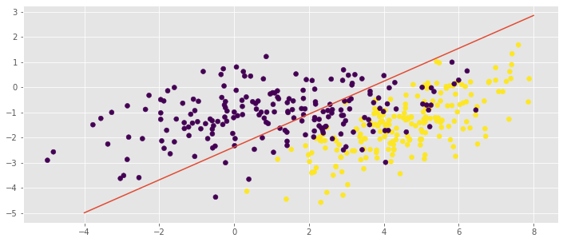

```python
np.random.seed(0)

C1 = np.array([[0., -0.8], [1.5, 0.8]])
C2 = np.array([[1., -0.7], [2., 0.7]])
gauss1 = np.dot(np.random.randn(200, 2) + np.array([5, 3]), C1)
gauss2 = np.dot(np.random.randn(200, 2) + np.array([1.5, 0]), C2)

X = np.vstack([gauss1, gauss2])
y = np.r_[np.ones(200), np.zeros(200)]

model = MySGDClassifier(batch_generator, model_type='log_reg', C=100, max_epoch=1000)
model.fit(X, y, batch_size=100)

plot_decision_boundary(model)
plt.scatter(X[:,0], X[:,1], c=y)
```

Далее будем анализировать Ваш алгоритм. Для этих заданий используйте датасет ниже.

```python
from sklearn.datasets import make_classification
```

```python
X, y = make_classification(n_samples=100000, n_features=10,
                           n_informative=4, n_redundant=0,
                           random_state=123, class_sep=1.0,
                           n_clusters_per_class=1)
```

Покажите сходимости обеих регрессией на этом датасете: изобразите график функции потерь, усредненной по $N$ шагам градиентого спуска, для разных `alpha` (размеров шага). Разные `alpha` расположите на одном графике.

$N$ можно брать 10, 50, 100 и т.д.

```python
lin = {}
log = {}
alphas = [0.1, 0.01, 0.001, 0.0001]
for alpha in alphas:
    model = MySGDClassifier(batch_generator, model_type='lin_reg', alpha=alpha)
    model.fit(X, y, batch_size=100)
    lin[alpha] = model.errors_log

    model = MySGDClassifier(batch_generator, model_type='log_reg', alpha=alpha)
    model.fit(X, y, batch_size=100)
    log[alpha] = model.errors_log
```

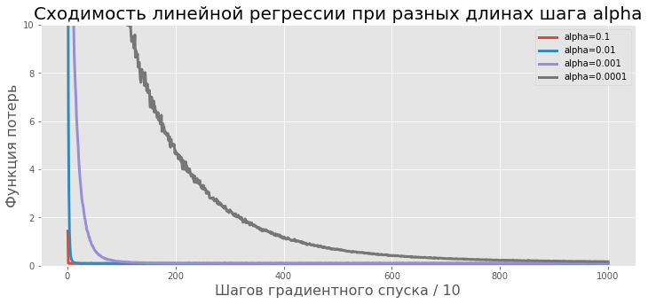

```python
plt.title('Сходимость линейной регрессии при разных длинах шага alpha', fontsize=20)
plt.ylabel('Функция потерь', fontsize=16)
plt.xlabel('Шагов градиентного спуска / 10', fontsize=16)
for alpha in alphas:
    plt.ylim([0, 10])
    plt.plot(np.arange(1, 1001, 1),
             np.mean(np.array(lin[alpha]['loss']).reshape(1000, 10), axis=1),
             label='alpha={}'.format(alpha),
             linewidth=3)
plt.legend()
```

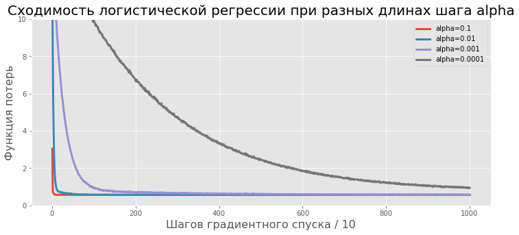

```python
plt.title('Сходимость логистической регрессии при разных длинах шага alpha', fontsize=20)
plt.ylabel('Функция потерь', fontsize=16)
plt.xlabel('Шагов градиентного спуска / 10', fontsize=16)
for alpha in alphas:
    plt.ylim([0, 10])
    plt.plot(np.arange(1, 1001, 1),
             np.mean(np.array(log[alpha]['loss']).reshape(1000, 10), axis=1),
             label='alpha={}'.format(alpha),
             linewidth=3)
plt.legend()
```

**Рассмотрим ближе**

[figure not shown]

```python
plt.title('Сходимость линейной регрессии при разных длинах шага alpha', fontsize=20)
plt.ylabel('Функция потерь', fontsize=16)
plt.xlabel('Шагов градиентного спуска / 100', fontsize=16)
for alpha in alphas:
    plt.ylim([0, 10])
    plt.xlim([1, 50])
    plt.plot(np.arange(1, 1001, 1),
             np.mean(np.array(lin[alpha]['loss']).reshape(1000, 10), axis=1),
             label='alpha={}'.format(alpha),
             linewidth = 3)
plt.legend()
```

[figure not shown]

```python
plt.title('Сходимость логистической регрессии при разных длинах шага alpha', fontsize=20)
plt.ylabel('Функция потерь', fontsize=16)
plt.xlabel('Шагов градиентного спуска / 100', fontsize=16)
for alpha in alphas:
    plt.ylim([0, 10])
    plt.xlim([1, 50])
    plt.plot(np.arange(1, 1001, 1),
             np.mean(np.array(log[alpha]['loss']).reshape(1000, 10), axis=1),
             label='alpha={}'.format(alpha),
             linewidth=3)
plt.legend()
```

Что Вы можете сказать про сходимость метода при различных `alpha`? Какое значение стоит выбирать для лучшей сходимости?

**Очевидно, что в обоих случаях при большом шаге alpha модель сходится быстрее, чем при меньших. Однако, в других задачах уменьшение шага может помочь более точно отыскать минимум при более долгой сходимости**

Изобразите график среднего значения весов для обеих регрессий в зависимости от коеф. регуляризации С из `np.logspace(3, -3, 10)`

```python
weights_lin = []
weights_log = []
for C in np.logspace(3, -3, 10):
    model = MySGDClassifier(
        batch_generator,
        model_type='lin_reg',
        alpha=0.0001,
        max_epoch=10,
        C=C)
    model.fit(X, y, batch_size=1000)
    weights_lin.append(model.weights[1:].mean())

    model = MySGDClassifier(
        batch_generator,
        model_type='log_reg',
        alpha=0.0001,
        max_epoch=10,
        C=C)
    model.fit(X, y, batch_size=1000)
    weights_log.append(model.weights[1:].mean())
```

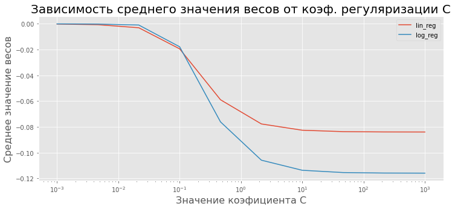

```python
plt.title("Зависимость среднего значения весов от коэф. регуляризации С", fontsize=20)
plt.ylabel('Среднее значение весов', fontsize=16)
plt.xlabel('Значение коэфициента C', fontsize=16)
plt.xscale('log')
plt.plot(np.logspace(3, -3, 10), weights_lin, label='lin_reg')
plt.plot(np.logspace(3, -3, 10), weights_log, label='log_reg')
plt.legend()
```

Довольны ли Вы, насколько сильно уменьшились Ваши веса?

**Среднее значение веса стало близким к нулю, поэтому можно быть довольным результатом. Однако, не стоит брать значение коэф. С слишком маленьким, так как это отдает слишком большое предпочтение уменьшению веса, нежели точности алгоритма.**

# Боевое применение (4 балла)

**Защита данной части возможна только при преодолении в проекте бейзлайна Handmade baseline.**

Давайте применим модель на итоговом проекте! Датасет сделаем точно таким же образом, как было показано в project_overview.ipynb

Применим обе регрессии, подберем для них параметры и сравним качество. Может быть Вы еще одновременно с решением домашней работы подрастете на лидерборде!

```python
doc_to_title = {}
with open('docs_titles.tsv') as f:
    for num_line, line in enumerate(f):
        if num_line == 0:
            continue
        data = line.strip().split('\t', 1)
        doc_id = int(data[0])
        if len(data) == 1:
            title = ''
        else:
            title = data[1]
        doc_to_title[doc_id] = title
print (len(doc_to_title))
```

```
28026
```

```python
import pandas as pd
train_data = pd.read_csv('train_groups.csv')
traingroups_titledata = {}
for i in range(len(train_data)):
    new_doc = train_data.iloc[i]
    doc_group = new_doc['group_id']
    doc_id = new_doc['doc_id']
    target = new_doc['target']
    title = doc_to_title[doc_id]
    if doc_group not in traingroups_titledata:
        traingroups_titledata[doc_group] = []
    traingroups_titledata[doc_group].append((doc_id, title, target))
```

```python
import numpy as np
y_train = []
X_train = []
groups_train = []
for new_group in traingroups_titledata:
    docs = traingroups_titledata[new_group]
    for k, (doc_id, title, target_id) in enumerate(docs):
        y_train.append(target_id)
        groups_train.append(new_group)
        all_dist = []
        words = set(title.strip().split())
        for j in range(0, len(docs)):
            if k == j:
                continue
            doc_id_j, title_j, target_j = docs[j]
            words_j = set(title_j.strip().split())
            all_dist.append(len(words.intersection(words_j)))
        X_train.append(sorted(all_dist, reverse=True)[0:15]    )
X_train = np.array(X_train)
y_train = np.array(y_train)
groups_train = np.array(groups_train)
print (X_train.shape, y_train.shape, groups_train.shape)
```

```
(11690, 15) (11690,) (11690,)
```

Подберите размер батча для обучения. Линейная модель не должна учиться дольше нескольких минут.

Не забывайте использовать скейлер!

```python
from sklearn.metrics import f1_score
from sklearn.linear_model import LinearRegression
from sklearn.preprocessing import StandardScaler
from sklearn.preprocessing import MinMaxScaler
from sklearn.model_selection import train_test_split
```

```python
X_train = StandardScaler().fit_transform(X=X_train)
```

Разбейте данные на обучение и валидацию. Подберите параметры C, alpha, max_epoch, model_type на валидации (Вы же помните, как правильно в этой задаче делать валидацию?)

```python
X_training, X_test, y_training, y_test = train_test_split(X_train, y_train, stratify=y_train)
parameters_lin = pd.DataFrame(columns=['alpha', 'C', 'max_epoch', 'batch_size', 'score', 'threshold'])
parameters_log = pd.DataFrame(columns=['alpha', 'C', 'max_epoch', 'batch_size', 'score', 'threshold'])
```

Подберите порог линейной модели, по достижении которого, Вы будете относить объект к классу 1. Вспомните, какую метрику мы оптимизируем в соревновании. Как тогда правильно подобрать порог?

```python
i = 0
for max_epoch in [1, 10, 50, 100, 200]:
    for alpha in [0.1, 0.01, 0.001, 0.0001]:
        for C in [1000, 100, 10, 1, 0.1, 0.01]:
            for batch_size in [10, 100, 1000, 10000]:

                lin_model = MySGDClassifier(
                    batch_generator,
                    C=C,
                    alpha=alpha,
                    max_epoch=max_epoch,
                    model_type='lin_reg')

                lin_model.fit(X_training, y_training, batch_size=batch_size)
                threshold = None
                score_f1 = 0
                pred = lin_model.predict(X_test)
                for thres in np.linspace(0, 1, 1000, endpoint=False):
                    score = f1_score(y_test,  pred > thres)
                    if score > score_f1:
                        score_f1 = score
                        threshold = thres

                parameters_lin = parameters_lin.append({
                    'alpha': alpha,
                    'C': C,
                    'max_epoch': max_epoch,
                    'batch_size': batch_size,
                    'score': score_f1,
                    'threshold': threshold
                }, ignore_index=True)

                print(parameters_lin.loc[[i]])

                log_model = MySGDClassifier(
                    batch_generator,
                    C=C,
                    alpha=alpha,
                    max_epoch=max_epoch,
                    model_type='log_reg')

                log_model.fit(X_training, y_training, batch_size=batch_size)
                threshold = None
                score_f1 = 0
                pred = log_model.predict(X_test)
                for thres in np.linspace(0, 1, 1000, endpoint=False):
                    score = f1_score(y_test, pred > thres)
                    if score > score_f1:
                        score_f1 = score
                        threshold = thres

                parameters_log = parameters_log.append({
                    'alpha': alpha,
                    'C': C,
                    'max_epoch': max_epoch,
                    'batch_size': batch_size,
                    'score': score_f1,
                    'threshold': threshold
                }, ignore_index=True)
                print(parameters_log.loc[[i]])
                i += 1
```

```
   alpha       C  max_epoch  batch_size     score  threshold
0    0.1  1000.0        1.0        10.0  0.205574        0.0
   alpha       C  max_epoch  batch_size     score  threshold
0    0.1  1000.0        1.0        10.0  0.606498      0.252
   alpha       C  max_epoch  batch_size     score  threshold
1    0.1  1000.0        1.0       100.0  0.611367        0.0
   alpha       C  max_epoch  batch_size     score  threshold
1    0.1  1000.0        1.0       100.0  0.585034      0.319
   alpha       C  max_epoch  batch_size     score  threshold
2    0.1  1000.0        1.0      1000.0  0.185575      0.314
   alpha       C  max_epoch  batch_size     score  threshold
2    0.1  1000.0        1.0      1000.0  0.561798      0.482
   alpha       C  max_epoch  batch_size    score  threshold
3    0.1  1000.0        1.0     10000.0  0.27156        0.0
   alpha       C  max_epoch  batch_size     score  threshold
3    0.1  1000.0        1.0     10000.0  0.537861      0.545
   alpha      C  max_epoch  batch_size     score  threshold
4    0.1  100.0        1.0        10.0  0.206021        0.0
   alpha      C  max_epoch  batch_size     score  threshold
4    0.1  100.0        1.0        10.0  0.610034       0.31
   alpha      C  max_epoch  batch_size     score  threshold
5    0.1  100.0        1.0       100.0  0.611367        0.0
   alpha      C  max_epoch  batch_size     score  threshold
5    0.1  100.0        1.0       100.0  0.592117      0.276
   alpha      C  max_epoch  batch_size     score  threshold
6    0.1  100.0        1.0      1000.0  0.185575      0.251
   alpha      C  max_epoch  batch_size     score  threshold
6    0.1  100.0        1.0      1000.0  0.561977      0.364
   alpha      C  max_epoch  batch_size    score  threshold
7    0.1  100.0        1.0     10000.0  0.27156      0.001
   alpha      C  max_epoch  batch_size     score  threshold
7    0.1  100.0        1.0     10000.0  0.537861      0.546
   alpha     C  max_epoch  batch_size     score  threshold
8    0.1  10.0        1.0        10.0  0.196151        0.0
   alpha     C  max_epoch  batch_size     score  threshold
8    0.1  10.0        1.0        10.0  0.614173      0.256
   alpha     C  max_epoch  batch_size     score  threshold
9    0.1  10.0        1.0       100.0  0.611367        0.0
   alpha     C  max_epoch  batch_size     score  threshold
9    0.1  10.0        1.0       100.0  0.613279      0.334
```

[output cut: 11 more lines]

```
12    0.1  1.0        1.0        10.0  0.614625      0.242
    alpha    C  max_epoch  batch_size     score  threshold
13    0.1  1.0        1.0       100.0  0.611452        0.0
    alpha    C  max_epoch  batch_size     score  threshold
13    0.1  1.0        1.0       100.0  0.613558      0.313
    alpha    C  max_epoch  batch_size     score  threshold
14    0.1  1.0        1.0      1000.0  0.185644        0.0
    alpha    C  max_epoch  batch_size     score  threshold
14    0.1  1.0        1.0      1000.0  0.617296      0.583
    alpha    C  max_epoch  batch_size     score  threshold
15    0.1  1.0        1.0     10000.0  0.249812       0.19
    alpha    C  max_epoch  batch_size     score  threshold
15    0.1  1.0        1.0     10000.0  0.543243      0.541
    alpha    C  max_epoch  batch_size     score  threshold
16    0.1  0.1        1.0        10.0  0.185435        0.0
```

```
    alpha    C  max_epoch  batch_size     score  threshold
16    0.1  0.1        1.0        10.0  0.446452        0.0
    alpha    C  max_epoch  batch_size    score  threshold
17    0.1  0.1        1.0       100.0  0.61057        0.0
```

```
    alpha    C  max_epoch  batch_size     score  threshold
17    0.1  0.1        1.0       100.0  0.614848      0.029
    alpha    C  max_epoch  batch_size     score  threshold
18    0.1  0.1        1.0      1000.0  0.185644        0.0
    alpha    C  max_epoch  batch_size     score  threshold
18    0.1  0.1        1.0      1000.0  0.446452        0.0
    alpha    C  max_epoch  batch_size     score  threshold
19    0.1  0.1        1.0     10000.0  0.199926      0.045
    alpha    C  max_epoch  batch_size     score  threshold
19    0.1  0.1        1.0     10000.0  0.446452        0.0
    alpha     C  max_epoch  batch_size     score  threshold
20    0.1  0.01        1.0        10.0  0.185644        0.0
```

```
    alpha     C  max_epoch  batch_size    score  threshold
20    0.1  0.01        1.0        10.0  0.26997        0.0
    alpha     C  max_epoch  batch_size    score  threshold
21    0.1  0.01        1.0       100.0  0.61214        0.0
```

```
    alpha     C  max_epoch  batch_size    score  threshold
21    0.1  0.01        1.0       100.0  0.49736        0.0
    alpha     C  max_epoch  batch_size     score  threshold
22    0.1  0.01        1.0      1000.0  0.176722        0.0
```

```
    alpha     C  max_epoch  batch_size     score  threshold
22    0.1  0.01        1.0      1000.0  0.272425        0.0
    alpha     C  max_epoch  batch_size     score  threshold
23    0.1  0.01        1.0     10000.0  0.260096      0.078
```

```
    alpha     C  max_epoch  batch_size     score  threshold
23    0.1  0.01        1.0     10000.0  0.446452        0.0
    alpha       C  max_epoch  batch_size     score  threshold
24   0.01  1000.0        1.0        10.0  0.540426      0.285
    alpha       C  max_epoch  batch_size    score  threshold
24   0.01  1000.0        1.0        10.0  0.58427      0.275
    alpha       C  max_epoch  batch_size    score  threshold
25   0.01  1000.0        1.0       100.0  0.47323        0.0
    alpha       C  max_epoch  batch_size     score  threshold
25   0.01  1000.0        1.0       100.0  0.559119      0.527
    alpha       C  max_epoch  batch_size    score  threshold
26   0.01  1000.0        1.0      1000.0  0.40513      0.093
    alpha       C  max_epoch  batch_size     score  threshold
26   0.01  1000.0        1.0      1000.0  0.537861      0.547
    alpha       C  max_epoch  batch_size     score  threshold
27   0.01  1000.0        1.0     10000.0  0.499305      0.259
    alpha       C  max_epoch  batch_size     score  threshold
27   0.01  1000.0        1.0     10000.0  0.528388      0.533
    alpha      C  max_epoch  batch_size     score  threshold
28   0.01  100.0        1.0        10.0  0.551509      0.269
    alpha      C  max_epoch  batch_size     score  threshold
28   0.01  100.0        1.0        10.0  0.591034      0.275
    alpha      C  max_epoch  batch_size     score  threshold
29   0.01  100.0        1.0       100.0  0.473684        0.0
    alpha      C  max_epoch  batch_size     score  threshold
29   0.01  100.0        1.0       100.0  0.560907      0.387
    alpha      C  max_epoch  batch_size    score  threshold
30   0.01  100.0        1.0      1000.0  0.40513      0.093
    alpha      C  max_epoch  batch_size     score  threshold
30   0.01  100.0        1.0      1000.0  0.537861      0.547
    alpha      C  max_epoch  batch_size     score  threshold
31   0.01  100.0        1.0     10000.0  0.499305      0.259
    alpha      C  max_epoch  batch_size     score  threshold
31   0.01  100.0        1.0     10000.0  0.528388      0.533
    alpha     C  max_epoch  batch_size     score  threshold
32   0.01  10.0        1.0        10.0  0.609781       0.29
    alpha     C  max_epoch  batch_size     score  threshold
32   0.01  10.0        1.0        10.0  0.615073      0.334
    alpha     C  max_epoch  batch_size     score  threshold
33   0.01  10.0        1.0       100.0  0.486509        0.0
```

[output cut: 29 more lines]

```
40   0.01  0.1        1.0        10.0  0.612987      0.331
    alpha    C  max_epoch  batch_size     score  threshold
41   0.01  0.1        1.0       100.0  0.613558       0.32
    alpha    C  max_epoch  batch_size     score  threshold
41   0.01  0.1        1.0       100.0  0.614625      0.571
    alpha    C  max_epoch  batch_size    score  threshold
42   0.01  0.1        1.0      1000.0  0.52164      0.407
    alpha    C  max_epoch  batch_size     score  threshold
42   0.01  0.1        1.0      1000.0  0.569702      0.612
    alpha    C  max_epoch  batch_size     score  threshold
43   0.01  0.1        1.0     10000.0  0.492523      0.347
    alpha    C  max_epoch  batch_size     score  threshold
43   0.01  0.1        1.0     10000.0  0.528388      0.555
    alpha     C  max_epoch  batch_size     score  threshold
44   0.01  0.01        1.0        10.0  0.185575        0.0
```

```
    alpha     C  max_epoch  batch_size     score  threshold
44   0.01  0.01        1.0        10.0  0.446452        0.0
    alpha     C  max_epoch  batch_size     score  threshold
45   0.01  0.01        1.0       100.0  0.610797        0.0
    alpha     C  max_epoch  batch_size     score  threshold
45   0.01  0.01        1.0       100.0  0.613625      0.599
    alpha     C  max_epoch  batch_size     score  threshold
46   0.01  0.01        1.0      1000.0  0.179894        0.0
    alpha     C  max_epoch  batch_size     score  threshold
46   0.01  0.01        1.0      1000.0  0.446452        0.0
    alpha     C  max_epoch  batch_size     score  threshold
47   0.01  0.01        1.0     10000.0  0.293241        0.0
    alpha     C  max_epoch  batch_size     score  threshold
47   0.01  0.01        1.0     10000.0  0.446452        0.0
    alpha       C  max_epoch  batch_size     score  threshold
48  0.001  1000.0        1.0        10.0  0.460463        0.0
    alpha       C  max_epoch  batch_size     score  threshold
48  0.001  1000.0        1.0        10.0  0.559119      0.526
    alpha       C  max_epoch  batch_size     score  threshold
49  0.001  1000.0        1.0       100.0  0.412644      0.006
    alpha       C  max_epoch  batch_size     score  threshold
49  0.001  1000.0        1.0       100.0  0.534745      0.547
    alpha       C  max_epoch  batch_size     score  threshold
50  0.001  1000.0        1.0      1000.0  0.504496      0.271
    alpha       C  max_epoch  batch_size     score  threshold
50  0.001  1000.0        1.0      1000.0  0.528388      0.533
    alpha       C  max_epoch  batch_size     score  threshold
51  0.001  1000.0        1.0     10000.0  0.525929      0.148
    alpha       C  max_epoch  batch_size     score  threshold
51  0.001  1000.0        1.0     10000.0  0.525253      0.534
    alpha      C  max_epoch  batch_size     score  threshold
52  0.001  100.0        1.0        10.0  0.464611      0.002
    alpha      C  max_epoch  batch_size     score  threshold
52  0.001  100.0        1.0        10.0  0.560907      0.387
    alpha      C  max_epoch  batch_size     score  threshold
53  0.001  100.0        1.0       100.0  0.412644      0.007
    alpha      C  max_epoch  batch_size     score  threshold
53  0.001  100.0        1.0       100.0  0.537861      0.547
    alpha      C  max_epoch  batch_size     score  threshold
54  0.001  100.0        1.0      1000.0  0.504496      0.271
```

[output cut: 215 more lines]

```
108    0.1  1.0       10.0        10.0  0.193525        0.0
     alpha    C  max_epoch  batch_size     score  threshold
108    0.1  1.0       10.0        10.0  0.614228      0.272
     alpha    C  max_epoch  batch_size    score  threshold
109    0.1  1.0       10.0       100.0  0.60998        0.0
     alpha    C  max_epoch  batch_size     score  threshold
109    0.1  1.0       10.0       100.0  0.614625      0.265
     alpha    C  max_epoch  batch_size     score  threshold
110    0.1  1.0       10.0      1000.0  0.610883        0.0
     alpha    C  max_epoch  batch_size     score  threshold
110    0.1  1.0       10.0      1000.0  0.614496      0.334
     alpha    C  max_epoch  batch_size    score  threshold
111    0.1  1.0       10.0     10000.0  0.61214      0.463
     alpha    C  max_epoch  batch_size     score  threshold
111    0.1  1.0       10.0     10000.0  0.615542      0.586
```

```
     alpha    C  max_epoch  batch_size     score  threshold
112    0.1  0.1       10.0        10.0  0.612391        0.0
```

```
     alpha    C  max_epoch  batch_size     score  threshold
112    0.1  0.1       10.0        10.0  0.613625      0.268
     alpha    C  max_epoch  batch_size     score  threshold
113    0.1  0.1       10.0       100.0  0.610429        0.0
```

```
     alpha    C  max_epoch  batch_size     score  threshold
113    0.1  0.1       10.0       100.0  0.615304      0.998
     alpha    C  max_epoch  batch_size     score  threshold
114    0.1  0.1       10.0      1000.0  0.610883        0.0
```

```
     alpha    C  max_epoch  batch_size     score  threshold
114    0.1  0.1       10.0      1000.0  0.615309      0.005
     alpha    C  max_epoch  batch_size    score  threshold
115    0.1  0.1       10.0     10000.0  0.61214        0.0
     alpha    C  max_epoch  batch_size     score  threshold
115    0.1  0.1       10.0     10000.0  0.615232      0.585
```

```
     alpha     C  max_epoch  batch_size  score  threshold
116    0.1  0.01       10.0        10.0    0.0        NaN
```

```
     alpha     C  max_epoch  batch_size  score  threshold
116    0.1  0.01       10.0        10.0    0.0        NaN
     alpha     C  max_epoch  batch_size     score  threshold
117    0.1  0.01       10.0       100.0  0.611596        0.0
```

```
     alpha     C  max_epoch  batch_size    score  threshold
117    0.1  0.01       10.0       100.0  0.49736        0.0
     alpha     C  max_epoch  batch_size     score  threshold
118    0.1  0.01       10.0      1000.0  0.611511        0.0
```

```
     alpha     C  max_epoch  batch_size    score  threshold
118    0.1  0.01       10.0      1000.0  0.49736        0.0
     alpha     C  max_epoch  batch_size     score  threshold
119    0.1  0.01       10.0     10000.0  0.611384        0.0
```

[output not shown]

[output cut: 29 more lines]

```
136   0.01  0.1       10.0        10.0  0.613277      0.291
     alpha    C  max_epoch  batch_size     score  threshold
137   0.01  0.1       10.0       100.0  0.614625      0.276
     alpha    C  max_epoch  batch_size     score  threshold
137   0.01  0.1       10.0       100.0  0.614321      0.328
     alpha    C  max_epoch  batch_size     score  threshold
138   0.01  0.1       10.0      1000.0  0.614625      0.323
     alpha    C  max_epoch  batch_size     score  threshold
138   0.01  0.1       10.0      1000.0  0.614321       0.57
     alpha    C  max_epoch  batch_size     score  threshold
139   0.01  0.1       10.0     10000.0  0.547562      0.496
     alpha    C  max_epoch  batch_size     score  threshold
139   0.01  0.1       10.0     10000.0  0.580892      0.616
     alpha     C  max_epoch  batch_size     score  threshold
140   0.01  0.01       10.0        10.0  0.612455        0.0
```

```
     alpha     C  max_epoch  batch_size     score  threshold
140   0.01  0.01       10.0        10.0  0.615304      0.998
     alpha     C  max_epoch  batch_size     score  threshold
141   0.01  0.01       10.0       100.0  0.610969        0.0
```

[output not shown]

[output cut: 147 more lines]

```
188  0.0001  0.01       10.0        10.0  0.614625      0.335
      alpha     C  max_epoch  batch_size     score  threshold
188  0.0001  0.01       10.0        10.0  0.613306      0.574
      alpha     C  max_epoch  batch_size     score  threshold
189  0.0001  0.01       10.0       100.0  0.614314      0.528
      alpha     C  max_epoch  batch_size     score  threshold
189  0.0001  0.01       10.0       100.0  0.614321      0.633
      alpha     C  max_epoch  batch_size     score  threshold
190  0.0001  0.01       10.0      1000.0  0.515738      0.409
      alpha     C  max_epoch  batch_size     score  threshold
190  0.0001  0.01       10.0      1000.0  0.533698      0.624
      alpha     C  max_epoch  batch_size     score  threshold
191  0.0001  0.01       10.0     10000.0  0.525929      0.227
      alpha     C  max_epoch  batch_size     score  threshold
191  0.0001  0.01       10.0     10000.0  0.525253      0.554
```

```
     alpha       C  max_epoch  batch_size     score  threshold
192    0.1  1000.0       50.0        10.0  0.167258        0.0
     alpha       C  max_epoch  batch_size     score  threshold
192    0.1  1000.0       50.0        10.0  0.620225      0.333
     alpha       C  max_epoch  batch_size     score  threshold
193    0.1  1000.0       50.0       100.0  0.611025        0.0
     alpha       C  max_epoch  batch_size     score  threshold
193    0.1  1000.0       50.0       100.0  0.619595      0.289
     alpha       C  max_epoch  batch_size    score  threshold
194    0.1  1000.0       50.0      1000.0  0.61214        0.0
     alpha       C  max_epoch  batch_size     score  threshold
194    0.1  1000.0       50.0      1000.0  0.601301      0.246
     alpha       C  max_epoch  batch_size    score  threshold
195    0.1  1000.0       50.0     10000.0  0.61214        0.0
     alpha       C  max_epoch  batch_size     score  threshold
195    0.1  1000.0       50.0     10000.0  0.572246      0.363
```

```
     alpha      C  max_epoch  batch_size     score  threshold
196    0.1  100.0       50.0        10.0  0.167258        0.0
     alpha      C  max_epoch  batch_size     score  threshold
196    0.1  100.0       50.0        10.0  0.619175      0.304
     alpha      C  max_epoch  batch_size     score  threshold
197    0.1  100.0       50.0       100.0  0.611025        0.0
     alpha      C  max_epoch  batch_size     score  threshold
197    0.1  100.0       50.0       100.0  0.622538       0.29
     alpha      C  max_epoch  batch_size    score  threshold
198    0.1  100.0       50.0      1000.0  0.61214        0.0
     alpha      C  max_epoch  batch_size     score  threshold
198    0.1  100.0       50.0      1000.0  0.609467      0.241
     alpha      C  max_epoch  batch_size    score  threshold
199    0.1  100.0       50.0     10000.0  0.61214        0.0
     alpha      C  max_epoch  batch_size     score  threshold
199    0.1  100.0       50.0     10000.0  0.578772      0.371
```

```
     alpha     C  max_epoch  batch_size     score  threshold
200    0.1  10.0       50.0        10.0  0.168363        0.0
     alpha     C  max_epoch  batch_size    score  threshold
200    0.1  10.0       50.0        10.0  0.62028      0.307
     alpha     C  max_epoch  batch_size     score  threshold
201    0.1  10.0       50.0       100.0  0.610711        0.0
     alpha     C  max_epoch  batch_size     score  threshold
201    0.1  10.0       50.0       100.0  0.617834      0.282
     alpha     C  max_epoch  batch_size    score  threshold
202    0.1  10.0       50.0      1000.0  0.61214        0.0
     alpha     C  max_epoch  batch_size     score  threshold
202    0.1  10.0       50.0      1000.0  0.615385      0.244
     alpha     C  max_epoch  batch_size    score  threshold
203    0.1  10.0       50.0     10000.0  0.61214        0.0
     alpha     C  max_epoch  batch_size     score  threshold
203    0.1  10.0       50.0     10000.0  0.607245      0.386
```

```
     alpha    C  max_epoch  batch_size     score  threshold
204    0.1  1.0       50.0        10.0  0.612808        0.0
     alpha    C  max_epoch  batch_size    score  threshold
204    0.1  1.0       50.0        10.0  0.61872      0.306
     alpha    C  max_epoch  batch_size     score  threshold
205    0.1  1.0       50.0       100.0  0.610711        0.0
     alpha    C  max_epoch  batch_size     score  threshold
205    0.1  1.0       50.0       100.0  0.615304      0.284
     alpha    C  max_epoch  batch_size    score  threshold
206    0.1  1.0       50.0      1000.0  0.61214        0.0
     alpha    C  max_epoch  batch_size     score  threshold
206    0.1  1.0       50.0      1000.0  0.614578      0.282
     alpha    C  max_epoch  batch_size    score  threshold
207    0.1  1.0       50.0     10000.0  0.61214        0.0
     alpha    C  max_epoch  batch_size     score  threshold
207    0.1  1.0       50.0     10000.0  0.614625      0.381
```

```
     alpha    C  max_epoch  batch_size  score  threshold
208    0.1  0.1       50.0        10.0    0.0        NaN
```

```
     alpha    C  max_epoch  batch_size     score  threshold
208    0.1  0.1       50.0        10.0  0.613625      0.005
```

```
     alpha    C  max_epoch  batch_size     score  threshold
209    0.1  0.1       50.0       100.0  0.610711        0.0
```

```
     alpha    C  max_epoch  batch_size     score  threshold
209    0.1  0.1       50.0       100.0  0.613625      0.527
     alpha    C  max_epoch  batch_size    score  threshold
210    0.1  0.1       50.0      1000.0  0.61214        0.0
```

```
     alpha    C  max_epoch  batch_size     score  threshold
210    0.1  0.1       50.0      1000.0  0.614338      0.982
     alpha    C  max_epoch  batch_size    score  threshold
211    0.1  0.1       50.0     10000.0  0.61214        0.0
```

```
     alpha    C  max_epoch  batch_size     score  threshold
211    0.1  0.1       50.0     10000.0  0.616832       0.14
```

```
     alpha     C  max_epoch  batch_size  score  threshold
212    0.1  0.01       50.0        10.0    0.0        NaN
```

```
     alpha     C  max_epoch  batch_size  score  threshold
212    0.1  0.01       50.0        10.0    0.0        NaN
```

```
     alpha     C  max_epoch  batch_size  score  threshold
213    0.1  0.01       50.0       100.0    0.0        NaN
```

```
     alpha     C  max_epoch  batch_size  score  threshold
213    0.1  0.01       50.0       100.0    0.0        NaN
     alpha     C  max_epoch  batch_size     score  threshold
214    0.1  0.01       50.0      1000.0  0.611511        0.0
```

```
     alpha     C  max_epoch  batch_size    score  threshold
214    0.1  0.01       50.0      1000.0  0.49736        0.0
     alpha     C  max_epoch  batch_size     score  threshold
215    0.1  0.01       50.0     10000.0  0.610883        0.0
```

[output not shown]

[output cut: 27 more lines]

```
232   0.01  0.1       50.0        10.0  0.617989      0.317
     alpha    C  max_epoch  batch_size     score  threshold
232   0.01  0.1       50.0        10.0  0.615303      0.292
     alpha    C  max_epoch  batch_size     score  threshold
233   0.01  0.1       50.0       100.0  0.615304      0.297
     alpha    C  max_epoch  batch_size     score  threshold
233   0.01  0.1       50.0       100.0  0.613625      0.288
     alpha    C  max_epoch  batch_size     score  threshold
234   0.01  0.1       50.0      1000.0  0.614578      0.294
     alpha    C  max_epoch  batch_size     score  threshold
234   0.01  0.1       50.0      1000.0  0.614263      0.406
     alpha    C  max_epoch  batch_size    score  threshold
235   0.01  0.1       50.0     10000.0  0.61462      0.383
     alpha    C  max_epoch  batch_size     score  threshold
235   0.01  0.1       50.0     10000.0  0.614321      0.599
```

```
     alpha     C  max_epoch  batch_size     score  threshold
236   0.01  0.01       50.0        10.0  0.610066        0.0
```

```
     alpha     C  max_epoch  batch_size     score  threshold
236   0.01  0.01       50.0        10.0  0.613625      0.471
     alpha     C  max_epoch  batch_size    score  threshold
237   0.01  0.01       50.0       100.0  0.61214        0.0
```

```
     alpha     C  max_epoch  batch_size     score  threshold
237   0.01  0.01       50.0       100.0  0.614338      0.982
     alpha     C  max_epoch  batch_size    score  threshold
238   0.01  0.01       50.0      1000.0  0.61214        0.0
```

[output not shown]

[output cut: 143 more lines]

```
284  0.0001  0.01       50.0        10.0  0.615304      0.289
      alpha     C  max_epoch  batch_size     score  threshold
284  0.0001  0.01       50.0        10.0  0.613375      0.408
      alpha     C  max_epoch  batch_size     score  threshold
285  0.0001  0.01       50.0       100.0  0.614321      0.405
      alpha     C  max_epoch  batch_size     score  threshold
285  0.0001  0.01       50.0       100.0  0.614173      0.606
      alpha     C  max_epoch  batch_size     score  threshold
286  0.0001  0.01       50.0      1000.0  0.613649      0.555
      alpha     C  max_epoch  batch_size     score  threshold
286  0.0001  0.01       50.0      1000.0  0.612717      0.637
      alpha     C  max_epoch  batch_size     score  threshold
287  0.0001  0.01       50.0     10000.0  0.517056      0.118
      alpha     C  max_epoch  batch_size     score  threshold
287  0.0001  0.01       50.0     10000.0  0.531022      0.602
```

```
     alpha       C  max_epoch  batch_size  score  threshold
288    0.1  1000.0      100.0        10.0    0.0        NaN
     alpha       C  max_epoch  batch_size     score  threshold
288    0.1  1000.0      100.0        10.0  0.617978      0.328
     alpha       C  max_epoch  batch_size     score  threshold
289    0.1  1000.0      100.0       100.0  0.609137        0.0
     alpha       C  max_epoch  batch_size    score  threshold
289    0.1  1000.0      100.0       100.0  0.61989      0.289
     alpha       C  max_epoch  batch_size     score  threshold
290    0.1  1000.0      100.0      1000.0  0.611511        0.0
     alpha       C  max_epoch  batch_size     score  threshold
290    0.1  1000.0      100.0      1000.0  0.608696      0.248
     alpha       C  max_epoch  batch_size    score  threshold
291    0.1  1000.0      100.0     10000.0  0.61214        0.0
     alpha       C  max_epoch  batch_size     score  threshold
291    0.1  1000.0      100.0     10000.0  0.581886      0.268
```

```
     alpha      C  max_epoch  batch_size  score  threshold
292    0.1  100.0      100.0        10.0    0.0        NaN
     alpha      C  max_epoch  batch_size     score  threshold
292    0.1  100.0      100.0        10.0  0.613244      0.321
     alpha      C  max_epoch  batch_size     score  threshold
293    0.1  100.0      100.0       100.0  0.609137        0.0
     alpha      C  max_epoch  batch_size    score  threshold
293    0.1  100.0      100.0       100.0  0.61742       0.29
     alpha      C  max_epoch  batch_size     score  threshold
294    0.1  100.0      100.0      1000.0  0.611511        0.0
     alpha      C  max_epoch  batch_size     score  threshold
294    0.1  100.0      100.0      1000.0  0.615468      0.284
     alpha      C  max_epoch  batch_size    score  threshold
295    0.1  100.0      100.0     10000.0  0.61214        0.0
     alpha      C  max_epoch  batch_size     score  threshold
295    0.1  100.0      100.0     10000.0  0.585505      0.279
```

```
     alpha     C  max_epoch  batch_size  score  threshold
296    0.1  10.0      100.0        10.0    0.0        NaN
     alpha     C  max_epoch  batch_size     score  threshold
296    0.1  10.0      100.0        10.0  0.615539      0.239
     alpha     C  max_epoch  batch_size     score  threshold
297    0.1  10.0      100.0       100.0  0.609137        0.0
     alpha     C  max_epoch  batch_size     score  threshold
297    0.1  10.0      100.0       100.0  0.615538      0.244
     alpha     C  max_epoch  batch_size     score  threshold
298    0.1  10.0      100.0      1000.0  0.611511        0.0
     alpha     C  max_epoch  batch_size     score  threshold
298    0.1  10.0      100.0      1000.0  0.615385      0.244
     alpha     C  max_epoch  batch_size    score  threshold
299    0.1  10.0      100.0     10000.0  0.61214        0.0
     alpha     C  max_epoch  batch_size     score  threshold
299    0.1  10.0      100.0     10000.0  0.614243      0.306
```

```
     alpha    C  max_epoch  batch_size  score  threshold
300    0.1  1.0      100.0        10.0    0.0        NaN
     alpha    C  max_epoch  batch_size     score  threshold
300    0.1  1.0      100.0        10.0  0.613851      0.289
     alpha    C  max_epoch  batch_size     score  threshold
301    0.1  1.0      100.0       100.0  0.609137        0.0
     alpha    C  max_epoch  batch_size     score  threshold
301    0.1  1.0      100.0       100.0  0.614173      0.283
     alpha    C  max_epoch  batch_size     score  threshold
302    0.1  1.0      100.0      1000.0  0.611511        0.0
     alpha    C  max_epoch  batch_size     score  threshold
302    0.1  1.0      100.0      1000.0  0.614321      0.263
     alpha    C  max_epoch  batch_size    score  threshold
303    0.1  1.0      100.0     10000.0  0.61214        0.0
     alpha    C  max_epoch  batch_size     score  threshold
303    0.1  1.0      100.0     10000.0  0.614578      0.323
```

```
     alpha    C  max_epoch  batch_size  score  threshold
304    0.1  0.1      100.0        10.0    0.0        NaN
```

```
     alpha    C  max_epoch  batch_size     score  threshold
304    0.1  0.1      100.0        10.0  0.613625      0.001
```

```
     alpha    C  max_epoch  batch_size  score  threshold
305    0.1  0.1      100.0       100.0    0.0        NaN
```

```
     alpha    C  max_epoch  batch_size     score  threshold
305    0.1  0.1      100.0       100.0  0.613625       0.32
     alpha    C  max_epoch  batch_size     score  threshold
306    0.1  0.1      100.0      1000.0  0.611511        0.0
```

```
     alpha    C  max_epoch  batch_size     score  threshold
306    0.1  0.1      100.0      1000.0  0.615304      0.998
     alpha    C  max_epoch  batch_size    score  threshold
307    0.1  0.1      100.0     10000.0  0.61214        0.0
```

```
     alpha    C  max_epoch  batch_size     score  threshold
307    0.1  0.1      100.0     10000.0  0.614928      0.006
```

```
     alpha     C  max_epoch  batch_size  score  threshold
308    0.1  0.01      100.0        10.0    0.0        NaN
```

```
     alpha     C  max_epoch  batch_size  score  threshold
308    0.1  0.01      100.0        10.0    0.0        NaN
```

```
     alpha     C  max_epoch  batch_size  score  threshold
309    0.1  0.01      100.0       100.0    0.0        NaN
```

```
     alpha     C  max_epoch  batch_size  score  threshold
309    0.1  0.01      100.0       100.0    0.0        NaN
     alpha     C  max_epoch  batch_size    score  threshold
310    0.1  0.01      100.0      1000.0  0.61214        0.0
```

```
     alpha     C  max_epoch  batch_size    score  threshold
310    0.1  0.01      100.0      1000.0  0.49736        0.0
     alpha     C  max_epoch  batch_size    score  threshold
311    0.1  0.01      100.0     10000.0  0.61214        0.0
```

[output not shown]

[output cut: 27 more lines]

```
328   0.01  0.1      100.0        10.0  0.614578      0.301
     alpha    C  max_epoch  batch_size     score  threshold
328   0.01  0.1      100.0        10.0  0.613768      0.289
     alpha    C  max_epoch  batch_size     score  threshold
329   0.01  0.1      100.0       100.0  0.614173      0.296
     alpha    C  max_epoch  batch_size     score  threshold
329   0.01  0.1      100.0       100.0  0.612819      0.288
     alpha    C  max_epoch  batch_size     score  threshold
330   0.01  0.1      100.0      1000.0  0.614625      0.275
     alpha    C  max_epoch  batch_size     score  threshold
330   0.01  0.1      100.0      1000.0  0.614321      0.326
     alpha    C  max_epoch  batch_size     score  threshold
331   0.01  0.1      100.0     10000.0  0.614625      0.314
     alpha    C  max_epoch  batch_size     score  threshold
331   0.01  0.1      100.0     10000.0  0.614321      0.563
```

```
     alpha     C  max_epoch  batch_size  score  threshold
332   0.01  0.01      100.0        10.0    0.0        NaN
```

```
     alpha     C  max_epoch  batch_size     score  threshold
332   0.01  0.01      100.0        10.0  0.613625      0.244
     alpha     C  max_epoch  batch_size     score  threshold
333   0.01  0.01      100.0       100.0  0.611511        0.0
```

```
     alpha     C  max_epoch  batch_size     score  threshold
333   0.01  0.01      100.0       100.0  0.615304      0.998
     alpha     C  max_epoch  batch_size    score  threshold
334   0.01  0.01      100.0      1000.0  0.61214        0.0
```

[output not shown]

[output cut: 143 more lines]

```
380  0.0001  0.01      100.0        10.0  0.613095      0.285
      alpha     C  max_epoch  batch_size     score  threshold
380  0.0001  0.01      100.0        10.0  0.611718      0.331
      alpha     C  max_epoch  batch_size     score  threshold
381  0.0001  0.01      100.0       100.0  0.613684      0.339
      alpha     C  max_epoch  batch_size     score  threshold
381  0.0001  0.01      100.0       100.0  0.608511      0.574
      alpha     C  max_epoch  batch_size     score  threshold
382  0.0001  0.01      100.0      1000.0  0.614314      0.527
      alpha     C  max_epoch  batch_size     score  threshold
382  0.0001  0.01      100.0      1000.0  0.609879      0.633
      alpha     C  max_epoch  batch_size     score  threshold
383  0.0001  0.01      100.0     10000.0  0.517056      0.406
      alpha     C  max_epoch  batch_size     score  threshold
383  0.0001  0.01      100.0     10000.0  0.533698      0.627
```

```
     alpha       C  max_epoch  batch_size  score  threshold
384    0.1  1000.0      200.0        10.0    0.0        NaN
     alpha       C  max_epoch  batch_size    score  threshold
384    0.1  1000.0      200.0        10.0  0.61727      0.291
```

```
     alpha       C  max_epoch  batch_size     score  threshold
385    0.1  1000.0      200.0       100.0  0.612033        0.0
     alpha       C  max_epoch  batch_size     score  threshold
385    0.1  1000.0      200.0       100.0  0.620728      0.296
     alpha       C  max_epoch  batch_size    score  threshold
386    0.1  1000.0      200.0      1000.0  0.61214        0.0
     alpha       C  max_epoch  batch_size     score  threshold
386    0.1  1000.0      200.0      1000.0  0.615385      0.291
     alpha       C  max_epoch  batch_size    score  threshold
387    0.1  1000.0      200.0     10000.0  0.61214        0.0
     alpha       C  max_epoch  batch_size     score  threshold
387    0.1  1000.0      200.0     10000.0  0.587465      0.223
```

```
     alpha      C  max_epoch  batch_size  score  threshold
388    0.1  100.0      200.0        10.0    0.0        NaN
     alpha      C  max_epoch  batch_size     score  threshold
388    0.1  100.0      200.0        10.0  0.614224      0.278
```

```
     alpha      C  max_epoch  batch_size     score  threshold
389    0.1  100.0      200.0       100.0  0.612033        0.0
     alpha      C  max_epoch  batch_size     score  threshold
389    0.1  100.0      200.0       100.0  0.620653      0.281
     alpha      C  max_epoch  batch_size    score  threshold
390    0.1  100.0      200.0      1000.0  0.61214        0.0
     alpha      C  max_epoch  batch_size    score  threshold
390    0.1  100.0      200.0      1000.0  0.62035      0.285
     alpha      C  max_epoch  batch_size    score  threshold
391    0.1  100.0      200.0     10000.0  0.61214        0.0
     alpha      C  max_epoch  batch_size     score  threshold
391    0.1  100.0      200.0     10000.0  0.598633       0.25
```

```
     alpha     C  max_epoch  batch_size  score  threshold
392    0.1  10.0      200.0        10.0    0.0        NaN
     alpha     C  max_epoch  batch_size     score  threshold
392    0.1  10.0      200.0        10.0  0.610837      0.245
```

```
     alpha     C  max_epoch  batch_size     score  threshold
393    0.1  10.0      200.0       100.0  0.612033        0.0
     alpha     C  max_epoch  batch_size    score  threshold
393    0.1  10.0      200.0       100.0  0.61462      0.246
     alpha     C  max_epoch  batch_size    score  threshold
394    0.1  10.0      200.0      1000.0  0.61214        0.0
     alpha     C  max_epoch  batch_size     score  threshold
394    0.1  10.0      200.0      1000.0  0.615385      0.244
     alpha     C  max_epoch  batch_size    score  threshold
395    0.1  10.0      200.0     10000.0  0.61214        0.0
     alpha     C  max_epoch  batch_size     score  threshold
395    0.1  10.0      200.0     10000.0  0.613277      0.286
```

```
     alpha    C  max_epoch  batch_size  score  threshold
396    0.1  1.0      200.0        10.0    0.0        NaN
     alpha    C  max_epoch  batch_size     score  threshold
396    0.1  1.0      200.0        10.0  0.614173      0.292
```

```
     alpha    C  max_epoch  batch_size     score  threshold
397    0.1  1.0      200.0       100.0  0.612351        0.0
     alpha    C  max_epoch  batch_size     score  threshold
397    0.1  1.0      200.0       100.0  0.613693      0.267
     alpha    C  max_epoch  batch_size    score  threshold
398    0.1  1.0      200.0      1000.0  0.61214        0.0
     alpha    C  max_epoch  batch_size     score  threshold
398    0.1  1.0      200.0      1000.0  0.614625      0.264
     alpha    C  max_epoch  batch_size    score  threshold
399    0.1  1.0      200.0     10000.0  0.61214        0.0
     alpha    C  max_epoch  batch_size    score  threshold
399    0.1  1.0      200.0     10000.0  0.61462      0.272
```

```
     alpha    C  max_epoch  batch_size  score  threshold
400    0.1  0.1      200.0        10.0    0.0        NaN
```

```
     alpha    C  max_epoch  batch_size     score  threshold
400    0.1  0.1      200.0        10.0  0.613625      0.001
```

```
     alpha    C  max_epoch  batch_size  score  threshold
401    0.1  0.1      200.0       100.0    0.0        NaN
```

```
     alpha    C  max_epoch  batch_size     score  threshold
401    0.1  0.1      200.0       100.0  0.613625      0.161
     alpha    C  max_epoch  batch_size    score  threshold
402    0.1  0.1      200.0      1000.0  0.61214        0.0
```

```
     alpha    C  max_epoch  batch_size     score  threshold
402    0.1  0.1      200.0      1000.0  0.612987      0.104
     alpha    C  max_epoch  batch_size    score  threshold
403    0.1  0.1      200.0     10000.0  0.61214        0.0
```

```
     alpha    C  max_epoch  batch_size     score  threshold
403    0.1  0.1      200.0     10000.0  0.613193      0.992
```

```
     alpha     C  max_epoch  batch_size  score  threshold
404    0.1  0.01      200.0        10.0    0.0        NaN
```

```
     alpha     C  max_epoch  batch_size  score  threshold
404    0.1  0.01      200.0        10.0    0.0        NaN
```

```
     alpha     C  max_epoch  batch_size  score  threshold
405    0.1  0.01      200.0       100.0    0.0        NaN
```

```
     alpha     C  max_epoch  batch_size  score  threshold
405    0.1  0.01      200.0       100.0    0.0        NaN
     alpha     C  max_epoch  batch_size    score  threshold
406    0.1  0.01      200.0      1000.0  0.61214        0.0
```

```
     alpha     C  max_epoch  batch_size    score  threshold
406    0.1  0.01      200.0      1000.0  0.49736        0.0
     alpha     C  max_epoch  batch_size    score  threshold
407    0.1  0.01      200.0     10000.0  0.61214        0.0
```

[output not shown]

[output cut: 27 more lines]

```
424   0.01  0.1      200.0        10.0  0.614173      0.303
     alpha    C  max_epoch  batch_size     score  threshold
424   0.01  0.1      200.0        10.0  0.612784      0.288
     alpha    C  max_epoch  batch_size  score  threshold
425   0.01  0.1      200.0       100.0  0.614      0.279
     alpha    C  max_epoch  batch_size     score  threshold
425   0.01  0.1      200.0       100.0  0.613161      0.285
     alpha    C  max_epoch  batch_size     score  threshold
426   0.01  0.1      200.0      1000.0  0.614625      0.275
     alpha    C  max_epoch  batch_size     score  threshold
426   0.01  0.1      200.0      1000.0  0.613306      0.294
     alpha    C  max_epoch  batch_size     score  threshold
427   0.01  0.1      200.0     10000.0  0.614819      0.301
     alpha    C  max_epoch  batch_size     score  threshold
427   0.01  0.1      200.0     10000.0  0.613861      0.502
```

```
     alpha     C  max_epoch  batch_size  score  threshold
428   0.01  0.01      200.0        10.0    0.0        NaN
```

```
     alpha     C  max_epoch  batch_size     score  threshold
428   0.01  0.01      200.0        10.0  0.613625      0.144
     alpha     C  max_epoch  batch_size     score  threshold
429   0.01  0.01      200.0       100.0  0.610711        0.0
```

```
     alpha     C  max_epoch  batch_size     score  threshold
429   0.01  0.01      200.0       100.0  0.612987      0.097
     alpha     C  max_epoch  batch_size     score  threshold
430   0.01  0.01      200.0      1000.0  0.611511        0.0
```

```
     alpha     C  max_epoch  batch_size     score  threshold
430   0.01  0.01      200.0      1000.0  0.613333      0.999
     alpha     C  max_epoch  batch_size    score  threshold
431   0.01  0.01      200.0     10000.0  0.61214        0.0
```

[output not shown]

[output cut: 139 more lines]

```
476  0.0001  0.01      200.0        10.0  0.613277      0.289
      alpha     C  max_epoch  batch_size     score  threshold
476  0.0001  0.01      200.0        10.0  0.609971      0.294
      alpha     C  max_epoch  batch_size     score  threshold
477  0.0001  0.01      200.0       100.0  0.614314      0.294
      alpha     C  max_epoch  batch_size     score  threshold
477  0.0001  0.01      200.0       100.0  0.610785      0.518
      alpha     C  max_epoch  batch_size     score  threshold
478  0.0001  0.01      200.0      1000.0  0.614173      0.491
      alpha     C  max_epoch  batch_size    score  threshold
478  0.0001  0.01      200.0      1000.0  0.61214      0.626
      alpha     C  max_epoch  batch_size     score  threshold
479  0.0001  0.01      200.0     10000.0  0.585601      0.553
      alpha     C  max_epoch  batch_size     score  threshold
479  0.0001  0.01      200.0     10000.0  0.579487      0.636
```

```python
parameters_log[parameters_log.score == parameters_log.score.max()]
```

|  | alpha | C | max_epoch | batch_size | score | threshold |
| --- | --- | --- | --- | --- | --- | --- |
| 197 | 0.1 | 100.0 | 50.0 | 100.0 | 0.622538 | 0.29 |

```python
parameters_log[parameters_log.score.max() - parameters_log.score < 0.001]
```

|  | alpha | C | max_epoch | batch_size | score | threshold |
| --- | --- | --- | --- | --- | --- | --- |
| 197 | 0.10 | 100.0 | 50.0 | 100.0 | 0.622538 | 0.290 |
| 220 | 0.01 | 100.0 | 50.0 | 10.0 | 0.622198 | 0.289 |

```python
test_data = pd.read_csv('test_groups.csv')
testgroups_titledata = {}
for i in range(len(test_data)):
    new_doc = test_data.iloc[i]
    doc_group = new_doc['group_id']
    doc_id = new_doc['doc_id']
    title = doc_to_title[doc_id]
    if doc_group not in testgroups_titledata:
        testgroups_titledata[doc_group] = []
    testgroups_titledata[doc_group].append((doc_id, title))
```

```python
X_control = []
groups_test = []
for new_group in testgroups_titledata:
    docs = testgroups_titledata[new_group]
    for k, (doc_id, title) in enumerate(docs):
        groups_test.append(new_group)
        all_dist = []
        words = set(title.strip().split())
        for j in range(0, len(docs)):
            if k == j:
                continue
            doc_id_j, title_j = docs[j]
            words_j = set(title_j.strip().split())
            all_dist.append(len(words.intersection(words_j)))
        X_control.append(sorted(all_dist, reverse=True)[0:15])
X_control = np.array(X_control)
groups_test = np.array(groups_test)
print (X_control.shape, groups_test.shape)
```

```
(16627, 15) (16627,)
```

```python
my_scaler = StandardScaler()
my_scaler = my_scaler.fit(X=X_train)
X_train = my_scaler.transform(X=X_train)
X_control = my_scaler.transform(X=X_control)
```

```python
X_train.shape
```

```
(11690, 15)
```

```python
y_train.shape
```

```
(11690,)
```

```python
X_control.shape
```

```
(16627, 15)
```

```python
model_1 = MySGDClassifier(
            batch_generator,
            C=10,
            alpha=0.1,
            max_epoch=10,
            model_type='log_reg')
```

```python
model_1.fit(X_train, y_train, batch_size=10)
```

```
MySGDClassifier(C=10, alpha=0.1,
                batch_generator=<function batch_generator at 0x7ffc91147e50>,
                model_type='log_reg')
```

```python
predict_1 = model_1.predict(X_train)
print("f1_score for model_1 on train = ", f1_score(y_train,  predict_1 > 0.29))
```

```
f1_score for model_1 on train =  0.6142343637670741
```

```python
answer = pd.DataFrame(test_data.pair_id, columns=['pair_id'])
predict_answer = model_1.predict(X_control) > 0.577
answer['target'] = predict_answer.astype(np.int64)
```

```python
answer.shape
```

```
(16627, 2)
```

```python
answer[answer.target > 0]
```

|  | pair_id | target |
| --- | --- | --- |
| 1 | 11692 | 1 |
| 2 | 11693 | 1 |
| 3 | 11694 | 1 |
| 4 | 11695 | 1 |
| 8 | 11699 | 1 |
| ... | ... | ... |
| 16619 | 28310 | 1 |
| 16620 | 28311 | 1 |
| 16624 | 28315 | 1 |
| 16625 | 28316 | 1 |
| 16626 | 28317 | 1 |

5081 rows × 2 columns

```python
answer.to_csv("answer.csv", index=False)
```

**При сдаче домашки Вам необходимо кроме ссылки на ноутбук показать Ваш ник на kaggle, под которым Вы залили решение, которое побило Handmade baseline.**

**Ник: Valerii_Smirnov**

# Фидбек (бесценно)

- Какие аспекты обучения линейных моделей Вам показались непонятными? Какое место стоит дополнительно объяснить?

- Здесь Вы можете оставить отзыв о этой домашней работе или о всем курсе.